# ORFE_Thesis

Nathan Botton

2024-04-11

The following is the code that performs the modeling and analysis for *Dynamic Price Relationships Among EV Battery Metals: A Cointegration and VECM Approach with Trading Strategy Applications*, my senior thesis for the Operations Research and Financial Engineering Department at Princeton University.

The overall goal of the study is to create a strategy that at each predetermined point in time trains a Vector Error Correction Model (VECM) on EV battery metals price data in a specified preceding time window, and makes a prediction for the next change in price of each metal in order to develop strong risk-adjusted trading performance.

# Data Preprocessing

### Load in the metals price data

PRICES, the only input to this code, is a .csv file in which the first column contains dates, and the subsequent columns contain the prices of each metal on that date. Price data for the metals was sourced from Datastream, accessed through WRDS.

```r
PRICES = read.csv("evmetalsprices4.csv")
names(PRICES) = c("Date", "Mo", "Li", "Cu", "Mn", "Co","Ni")
PRICES$Date = as.Date(PRICES$Date, format="%m/%d/%y")
PRICES = PRICES[c("Date", "Li", "Co", "Ni", "Mn","Cu")]
rownames(PRICES) = NULL
METALS = c("Li", "Co", "Ni", "Mn","Cu")


END_TRAINING = as.Date("2019-12-31")
END_DATA = as.Date("2024-1-4")

head(PRICES)
```

```
##         Date     Li    Co     Ni   Mn   Cu
## 1 2012-10-29 405000 25250 116800 2650 6148
## 2 2012-10-30 405000 25250 115300 2650 6148
## 3 2012-10-31 405000 25550 116300 2650 6179
## 4 2012-11-01 405000 25850 116400 2650 6179
## 5 2012-11-02 405000 25675 117000 2575 6206
## 6 2012-11-05 405000 24875 114700 2575 6115
```

### Functions to preprocess data, prepare for Johansen test, and perform Johansen test

```r
# Data preprocessing, log-price summary statistics, and log-price plot
handle_data = function(pricedata) {
    # take log of prices
    logprices = pricedata %>%
        mutate(across(-Date, log))

    # summary statistics
    logprices_long = pivot_longer(logprices, cols = -Date, names_to = "Metal",
                                  values_to = "Price")
    summary_stats_log = logprices_long %>%
        group_by(Metal) %>%
        summarise(
            Mean = mean(Price, na.rm = TRUE),
            Max = max(Price, na.rm = TRUE),
            Min = min(Price, na.rm = TRUE),
            StdDev = sd(Price, na.rm = TRUE),
            Skew = skewness(Price, type = 3, na.rm = TRUE),
            .groups = "drop")

    # plot log-prices
    logplot = ggplot(data = logprices_long, aes(x = Date, y = Price, color = Metal)) +
                  geom_line() +
                  theme_light(base_family = "Times") +
                  theme(
                    axis.title.x = element_text(size = 12, margin = margin(t = 15)),
                    axis.title.y = element_text(size = 12 , margin = margin(r = 15)),
                    plot.title = element_text(size = 18),
                    legend.title = element_text(size = 12),
                    legend.text = element_text(size = 10),
                    plot.margin = unit(c(0.5, 0.5, 0.5, 0.5), "cm")
                  ) +
                  labs(
                    title = "Log-Prices Over Time",
                    x = "Date",
                    y = "Log-Price",
                    color = "Metal"
                  ) +
                  scale_x_date(
                    date_breaks = "1 year",
                    date_labels = "%Y",
                    expand = c(0.01, 0)
                  ) +
                  guides(colour = guide_legend(override.aes = list(size=4)))

  return(list(logprices=logprices, logstats=summary_stats_log, logplot=logplot))
}


# Use ADF test to check for non-stationarity and determine optimal lag length
testprep = function(logprices) {
    logmatrix = data.matrix(logprices)[,-1] # remove date column
    adf_result = apply(logmatrix, 2, adf.test)
    # array of different lag length criteria
    var_result = VARselect(logmatrix, lag.max=15, type="both")
    aic = var_result$selection[1] # AIC

    return(list(adf=adf_result, aic=aic))
}


# Perform Johansen test
johansen = function(logprices, lag, long=FALSE) {
    logmatrix = data.matrix(logprices)[,-1] # remove date column


    # set edcet and spec to (trend,longrun) for full dataset and (const,transitory)
    # for windows, as long time frame will more likely exhibit trend, short time
    # frame will not
    if(long) {
        edcet = 'trend'
        spec = 'longrun'
    }
    else{
        edcet = 'const'
        spec = 'transitory'
    }

    # perform the Johansen test
    cajo_result = ca.jo(logmatrix,
        type = 'eigen',
        ecdet = edcet,
        K = lag,
        spec=spec,
        season = NULL,
        dumvar = NULL)

    # extract directly the number of cointegrating relationships using the 10%
    # critical value
    table = cajo_result@cval
    teststat = cajo_result@teststat
    nrel = 0
    if (teststat[5] > table[5,1]) {
        nrel = 1
        if (teststat[4] > table[4,1]) {
            nrel=2
            if (teststat[3] > table[3,1]) {
                nrel=3
                if (teststat[2] > table[2,1]) {
                    nrel=4
                }
            }
        }
    }

    # create linear combination of cointegrating relationship and test its stationarity
    cajo_evec = cajo_result@V[,1][1:ncol(logmatrix)]
    const = cajo_result@V[,1][ncol(logmatrix)+1]
    lin_comb = logmatrix %*% cajo_evec
    adf = adf.test(lin_comb)

    # visualize the cointegrating linear relationship
    plot_data = data.frame(Date = logprices$Date, LinComb = lin_comb,
                           ConstLine = -const)
    plot = ggplot(plot_data, aes(x = Date)) +
        geom_line(aes(y = LinComb), color = "black") +
        geom_hline(aes(yintercept = ConstLine), color = "red") +
        labs(x = "Date", y = "Value") +
        theme_minimal()

    return(list(cajo = cajo_result, adf = adf, plot = plot, nrel = nrel))
}
```

### Preprocess price data, show summary stats and plot log-prices

```r
pricedata = handle_data(PRICES)
LOGPRICES = pricedata$logprices
head(LOGPRICES)
```

```
##         Date       Li       Co       Ni       Mn       Cu
## 1 2012-10-29 12.91164 10.13658 11.66822 7.882315 8.723882
## 2 2012-10-30 12.91164 10.13658 11.65529 7.882315 8.723882
## 3 2012-10-31 12.91164 10.14839 11.66393 7.882315 8.728912
## 4 2012-11-01 12.91164 10.16007 11.66479 7.882315 8.728912
## 5 2012-11-02 12.91164 10.15327 11.66993 7.853605 8.733272
## 6 2012-11-05 12.91164 10.12162 11.65008 7.853605 8.718500
```

```r
pricedata$logstats
```

```
## # A tibble: 5 × 6
##   Metal  Mean   Max   Min StdDev  Skew
##   <chr> <dbl> <dbl> <dbl>  <dbl> <dbl>
## 1 Co    10.5  11.5   9.98  0.376 0.704
## 2 Cu     8.71  9.17  8.33  0.207 0.635
## 3 Li    13.5  15.0  12.9   0.617 0.996
## 4 Mn     7.74  8.93  7.30  0.336 2.04
## 5 Ni    11.6  12.6  11.1   0.298 0.495
```

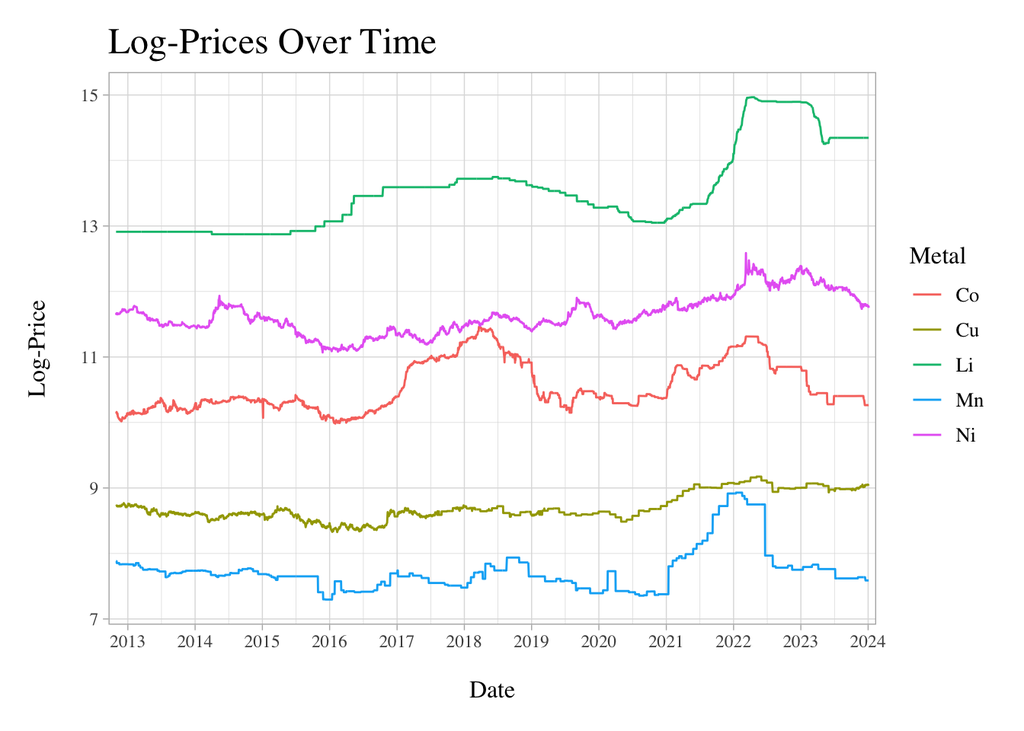

```r
fig1_logprices = pricedata$logplot
#ggsave("fig1_logprices.pdf", plot = fig1_logprices, device = "pdf", width = 8, height = 4)
fig1_logprices
```

# Testing for Cointegration

### Test sample data for stationarity, determine optimal lag length, and test for cointegration

```r
PRICES_sample = PRICES[PRICES$Date <= END_TRAINING, ]
LOGPRICES_sample = handle_data(PRICES_sample)$logprices

print("Stationarity of log-prices:")
```

```
## [1] "Stationarity of log-prices:"
```

```r
adf.test(LOGPRICES_sample$Li)$p.value
```

```
## [1] 0.99
```

```r
adf.test(LOGPRICES_sample$Co)$p.value
```

```
## [1] 0.9371369
```

```r
adf.test(LOGPRICES_sample$Ni)$p.value
```

```
## [1] 0.6231921
```

```r
adf.test(LOGPRICES_sample$Mn)$p.value
```

```
## [1] 0.3769093
```

```r
adf.test(LOGPRICES_sample$Cu)$p.value
```

```
## [1] 0.2983156
```

```r
print("Stationarity of log-price diffs:")
```

```
## [1] "Stationarity of log-price diffs:"
```

```r
adf.test(diff(LOGPRICES_sample$Li))$p.value
```

```
## [1] 0.01
```

```r
adf.test(diff(LOGPRICES_sample$Co))$p.value
```

```
## [1] 0.01
```

```r
adf.test(diff(LOGPRICES_sample$Ni))$p.value
```

```
## [1] 0.01
```

```r
adf.test(diff(LOGPRICES_sample$Mn))$p.value
```

```
## [1] 0.01
```

```r
adf.test(diff(LOGPRICES_sample$Cu))$p.value
```

```
## [1] 0.01
```

```r
aic = testprep(LOGPRICES_sample)$aic
aic
```

```
## AIC(n)
##      2
```

```r
sample_cajo = johansen(LOGPRICES_sample,aic,long=TRUE)
print('Cointegration Vector')
```

```
## [1] "Cointegration Vector"
```

```r
sample_cajo$cajo@V[,1]
```

```
##         Li.l2         Co.l2         Ni.l2         Mn.l2         Cu.l2
##  1.0000000000 -0.0726753050  0.3594428439 -1.6164796528  0.1151751100
##      trend.l2
## -0.0007080606
```

```r
summary(sample_cajo$cajo)
```

```
##
## ######################
## # Johansen-Procedure #
## ######################
##
## Test type: maximal eigenvalue statistic (lambda max) , with linear trend in cointegration
##
## Eigenvalues (lambda):
## [1] 1.986795e-02 1.179777e-02 1.121712e-02 3.806138e-03 1.204308e-03
## [6] 1.421940e-18
##
## Values of teststatistic and critical values of test:
##
##           test 10pct  5pct  1pct
## r <= 4 |  2.25 10.49 12.25 16.26
## r <= 3 |  7.13 16.85 18.96 23.65
## r <= 2 | 21.09 23.11 25.54 30.34
## r <= 1 | 22.19 29.12 31.46 36.65
## r = 0  | 37.53 34.75 37.52 42.36
##
## Eigenvectors, normalised to first column:
## (These are the cointegration relations)
##
##                  Li.l2         Co.l2        Ni.l2         Mn.l2        Cu.l2
## Li.l2     1.0000000000  1.0000000000  1.000000000  1.0000000000  1.000000000
## Co.l2    -0.0726753050 -0.7103112091  0.116416675 -0.8334848978  0.148122750
## Ni.l2     0.3594428439  1.1851639823  2.574716647 -0.1813250224 -3.834308064
## Mn.l2    -1.6164796528 -1.3101923291  0.065415322  1.3367382715 -0.670317426
## Cu.l2     0.1151751100  5.6486190133 -4.480061691 -0.0277850439  5.387312350
## trend.l2 -0.0007080606 -0.0003092317 -0.000289579 -0.0001174157  0.001836844
##              trend.l2
## Li.l2     1.000000000
## Co.l2     1.365339518
## Ni.l2    -0.491892867
## Mn.l2     1.979451137
## Cu.l2    -1.303308281
## trend.l2 -0.001192152
##
## Weights W:
## (This is the loading matrix)
##
##             Li.l2         Co.l2         Ni.l2         Mn.l2         Cu.l2
## Li.d 0.0023139744 -0.0011028653 -0.0011096978 -0.0001168324 -3.876443e-05
## Co.d 0.0073654581  0.0016366964 -0.0004984931  0.0032265512 -1.059407e-04
## Ni.d 0.0020268894 -0.0006258263  0.0003144475  0.0013468581  2.721985e-04
## Mn.d 0.0064484087  0.0005715315  0.0015998073 -0.0027807997  3.674237e-05
## Cu.d 0.0009303201 -0.0010244312  0.0027840030  0.0010798868 -3.664086e-05
##           trend.l2
## Li.d -2.383485e-16
## Co.d  3.749613e-15
## Ni.d -8.523905e-16
## Mn.d -1.595767e-15
## Cu.d -5.847064e-15
```

# Model and Strategy Formulation

## Determining the Optimal Lookback Window

### Iterate through different length time windows at various start dates to determine optimal cointegration window

```r
starts = c(as.Date("2013-1-1"), as.Date("2013-6-30"), as.Date("2014-1-1"),
           as.Date("2014-6-30"), as.Date("2015-1-1"), as.Date("2015-6-30"),
           as.Date("2016-1-1"), as.Date("2016-6-30"), as.Date("2017-1-1"),
           as.Date("2017-6-30"), as.Date("2018-1-1"), as.Date("2018-6-30"),
           as.Date("2019-1-1"), as.Date("2019-6-30"))
months = c(18,24,30,36,42,48,54,60,66,72)

# store results
stats = matrix(vector("list", length(starts) * length(months)),
               nrow = length(starts), ncol = length(months))

# test different window lengths over different time frames
for(i in 1:length(starts)){
    for(j in 1:length(months)){
        e = as.Date(starts[i]) + months(months[j])
        # skip if range would exceed past end of training data
        if(e > END_TRAINING) {next}
         # extract relevant price data window
        prices_cut = PRICES[PRICES$Date >= starts[i] & PRICES$Date <= e, ]

        # prepare data and perform Johansen test
        handled_data = handle_data(prices_cut)
        logprices = handled_data$logprices
        prep = testprep(logprices)
        aic = prep$aic
        if(aic<2){aic=2}  # Johansen test takes minimum lag length of 2
        johansen_test = johansen(logprices,aic)

        # extract relevant metrics
        # check for non-stationarity in all log-price series
        nonstationary = all(sapply(prep$adf, function(x) x$p.value) > .05)
        max_eval = (johansen_test$cajo)@lambda[1]   # check max eval
        # check for stationarity in cointegrating linear combination
        stationary = (johansen_test$adf)$p.value
        nrel = johansen_test$nrel
        if (nrel==0) {max_eval=0}

        stats[[i, j]] = list(starts[i], months[j], nonstationary, max_eval,
                             stationary, nrel)
    }
}

# create dataframe of results for easy viewing
stats_df = data.frame(Start = character(),
                         Month = numeric(),
                         Nonstationary = logical(),
                         Max_Eval = numeric(),
                         Stationary = numeric(),
                         NumRel= numeric())

for(i in 1:length(starts)){
    for(j in 1:length(months)){
        start_date = stats[[i, j]][[1]]
        month_duration = stats[[i, j]][[2]]
        nonstationary = stats[[i, j]][[3]]
        max_eval = stats[[i, j]][[4]]
        stationary = stats[[i, j]][[5]]
        numrel = stats[[i, j]][[6]]

        stats_df = rbind(stats_df, data.frame(Start = start_date,
                                                    Month = month_duration,
                                                    Nonstationary = nonstationary,
                                                    Max_Eval = max_eval,
                                                    Stationary = stationary,
                                                    NumRel = numrel))
    }
}

# order by window length, calculate instances of cointegration (%) and see results
stats_df$coint = (stats_df$NumRel != 0)
stats_df = stats_df[order(stats_df$Month), ]
#print(stats_df)
stats_df_summary = stats_df %>% group_by(Month) %>%
    summarise(MaxEval = mean(Max_Eval), Coint = mean(coint))
print(stats_df_summary)
```

```
## # A tibble: 10 × 3
##    Month MaxEval Coint
##    <dbl>   <dbl> <dbl>
##  1    18  0.0433 0.417
##  2    24  0.0443 0.6
##  3    30  0.0308 0.5
##  4    36  0.0295 0.625
##  5    42  0.0211 0.5
##  6    48  0.0242 0.667
##  7    54  0.0210 0.667
##  8    60  0.0217 0.75
##  9    66  0.0131 0.5
## 10    72  0.0117 0.5
```

## Train the VECMs according to trade strategy and make predictions

### Make predictions over a certain timeframe with a certain prediction frequency and lookback window

```r
# Every nahead-th day from startdate until enddate, train a VECM using price data
# from WINDOW months back from startdate, and make a prediction for nahead days out.
makepredictions = function(startdate, WINDOW, nahead, enddate) {
   # extract list of trading dates to make predictions on
    datelist = (PRICES$Date)[PRICES$Date >= startdate & PRICES$Date <= enddate]

    predictions = data.frame()

    # calulate % time VECMs are used
    count=0
    var=0

    # track cointegration vectors- artificially add first row in case predictions
    # start with VAR in which case the most recent cointegration vector from a
    # VECM is pulled forward
    rels = data.frame(Date = as.Date("2000-01-01"),
                      Li = 1, Co = 0, Ni = 0, Mn = 0, Cu = 0)

    # at every nahead date,
    for (i in seq(1, length(datelist), by = nahead)) {
        d = datelist[i]
        pred_date = as.Date(d)
        count = count+1

        # train on past WINDOW months
        window_start = pred_date - days(WINDOW*30)
        prices_cut = PRICES[PRICES$Date >= window_start & PRICES$Date <= pred_date, ]

        handled_data = handle_data(prices_cut)
        logprices = handled_data$logprices
        logmatrix = data.matrix(logprices)[,-1]
        # calculate volatility for each metal in its window
        vols = apply(logmatrix, 2, function(x) sd(x, na.rm = TRUE))

        aic=testprep(logprices)$aic
        if(aic<2){aic=2}
        nrel = johansen(logprices,aic)$nrel
        if(nrel==0){
            var=var+1
            # use VAR model if no cointegrating relationships are found
            var_model = VAR(logmatrix, p = aic-1, type = "const")
            pred = predict(var_model, n.ahead = nahead)$fcst
            pred = sapply(pred, function(fcst) fcst[1, "fcst"])
            # if using VAR just fill rels with last cointegrating vector
            rels = rbind(rels, c(list(Date = d),
                                 setNames(as.list(rels[nrow(rels), -1]), METALS)))

        }
        else{
            # train VECM (takes in lag used for Johansen-1)
            vecm = VECM(logmatrix, lag=aic-1, r=nrel, include="const")
            pred = predict(vecm, n.ahead=nahead)
            pred = pred[nrow(pred),]
            # extract cointegration vector
            coeffs = setNames(as.numeric(coefB(vecm)[, 1]), METALS)
            new_row = c(list(Date = d), as.list(coeffs))
            rels = rbind(rels, new_row)

        }

        # add at each date, the prediction for nahead points ahead,
        # and the volatility at the time
        new_row = data.frame(Date = d, Li = pred[1], Co = pred[2],
                            Ni = pred[3], Mn = pred[4], Cu = pred[5],
                            vLi = vols[1], vCo = vols[2], vNi = vols[3],
                            vMn = vols[4], vCu = vols[5])

        predictions = rbind(predictions, new_row)
    }

    # at each day, show actual price on that day and prediction for nahead points in time
    aligned_prices = merge(predictions, LOGPRICES, by = "Date", suffixes = c("_p", "_a"))

    # calculate expected and actual change, and signal nec
    for (metal in METALS) {
        aligned_prices[[paste0("ec", metal)]] = aligned_prices[[paste0(metal, "_p")]] -
            aligned_prices[[paste0(metal, "_a")]]
        aligned_prices[[paste0("ac", metal)]] =
            diff(c(aligned_prices[[paste0(metal, "_a")]], rep(NA, nahead)), lag = nahead)
        aligned_prices[[paste0("nec", metal)]] = aligned_prices[[paste0("ec", metal)]] /
            aligned_prices[[paste0("v", metal)]]
    }
    print(paste0('% times VECM used: ', 1-var/count))


    rels = rels[-1, ]  # take out aritifically added first row
    rels = rels[rels$Ni != 0, ] # remove first instances of VAR if that is the case

    return(list(aligned_prices = aligned_prices, rels=rels))
}
```

## Create RMSE and Directional Accuracy Evaluation

```r
# evaluate rmses, directional accuracy for nonzero changes, mean prediction for
# zero changes, and probability of better than random
evalmetrics = function(predictions){
    rmses = vector("numeric", length(METALS))
    names(rmses) = METALS
    actual_sd = vector("numeric", length(METALS))
    names(actual_sd) = METALS
    danz =  vector("numeric", length(METALS))
    names(danz) = METALS
    zero_preds = numeric()

    num_nz_guesses = 0
    num_correct_nz_guesses = 0
    for (metal in METALS) {
        # RMSE
        errors = predictions[[paste0("ac",metal)]] -
            predictions[[paste0("ec",metal)]]
        rmses[metal] = sqrt(mean(errors^2, na.rm = TRUE))
        # actual sd
        actual_sd[metal] = sd(predictions[[paste0("ac",metal)]], na.rm=TRUE)

        # mean guess when actual change is zero
        zero_changes = predictions[predictions[[paste0("ac",metal)]] == 0,
                                   paste0("ec",metal)]
        zero_preds = c(zero_preds,zero_changes)

        # directional accuracy for nonzero changes
        nonzero_changes = predictions[predictions[[paste0("ac",metal)]] != 0, ]
        correct_pred = (sign(nonzero_changes[[paste0("ac",metal)]]) ==
                            sign(nonzero_changes[[paste0("ec",metal)]]))
        danz[metal] = mean(correct_pred, na.rm=TRUE)

        num_nz_guesses = num_nz_guesses +
            sum(!is.na(nonzero_changes[[paste0("ac",metal)]]))
        num_correct_nz_guesses = num_correct_nz_guesses +
            sum(correct_pred, na.rm=TRUE)


    }

    mzero = mean(zero_preds, na.rm=TRUE)
    prob_random = 1 - pbinom(num_correct_nz_guesses-1, num_nz_guesses, 0.5)


    return(list(rmses=rmses, danz=danz, sd=actual_sd, mz=mzero, prob_random = prob_random))
}
```

## Determine Optimal Trading Frequency

```r
gaps = c(1,5,10,15,20,30)

gap_stats = data.frame(
  da_nz = numeric(length(gaps)),
  pr = numeric(length(gaps)),
  rmse = numeric(length(gaps))
)
rownames(gap_stats) = gaps

for (i in 1:length(gaps)){
    if (TRUE) {next}    # skip entire loop because of time it takes,
                        #comment out if need to run
    pred = makepredictions(as.Date("2015-1-1"), 24,
                           gaps[i], END_TRAINING)$aligned_prices
    met = evalmetrics(pred)
    gap_stats[i, "da_nz"] = mean(met$danz)
    gap_stats[i, "rmse"] = mean(met$rmse)
}
#gap_stats      # comment or uncomment opposite the if statement
```

# Evaluate Model on Sample Data

### Make Predictions on Sample Data

```r
BEGIN= as.Date("2015-1-1")
END= END_TRAINING
makepreds = makepredictions(BEGIN, 24, 5, END)
```

```
## [1] "% times VECM used: 0.609195402298851"
```

```r
predictions = makepreds$aligned_prices
head(predictions)
```

```
##         Date     Li_p     Co_p     Ni_p     Mn_p     Cu_p        vLi        vCo
## 1 2015-01-01 12.87410 10.35319 11.59253 7.685764 8.598404 0.01835977 0.08081450
## 2 2015-01-08 12.87409 10.35152 11.61633 7.686015 8.609767 0.01844456 0.08051439
## 3 2015-01-15 12.87388 10.33818 11.58472 7.684387 8.535313 0.01852171 0.08000249
## 4 2015-01-22 12.87390 10.33230 11.60718 7.684575 8.546617 0.01859130 0.07963005
## 5 2015-01-29 12.87383 10.30300 11.59555 7.677195 8.514088 0.01865342 0.07865041
## 6 2015-02-05 12.87393 10.30188 11.59050 7.678033 8.540469 0.01870815 0.07757690
##         vNi        vMn        vCu    Li_a     Co_a     Ni_a     Mn_a     Cu_a
## 1 0.1224737 0.04660516 0.05407168 12.8739 10.35361 11.59174 7.684784 8.599879
## 2 0.1219163 0.04557846 0.05290788 12.8739 10.35364 11.61593 7.684784 8.611412
## 3 0.1213376 0.04448085 0.05180422 12.8739 10.33444 11.58105 7.684784 8.534050
## 4 0.1206129 0.04330693 0.05094346 12.8739 10.32941 11.60368 7.684784 8.545586
## 5 0.1194067 0.04257180 0.04986209 12.8739 10.29621 11.58989 7.677864 8.511376
## 6 0.1182445 0.04140009 0.04821964 12.8739 10.29708 11.58571 7.677864 8.538759
##            ecLi acLi         necLi          ecCo        acCo        necCo
```

[output cut: 20 more lines]

### Evaluate Sample Data: RMSEs, directional accuracy, probability of randomness

```r
metrics = evalmetrics(predictions)
print("RMSEs:")
```

```
## [1] "RMSEs:"
```

```r
print(metrics$rmses)
```

```
##         Li         Co         Ni         Mn         Cu
## 0.05378305 0.11183025 0.07934658 0.09172206 0.05232956
```

```r
print("Actual sds:")
```

```
## [1] "Actual sds:"
```

```r
print(metrics$sd)
```

```
##         Li         Co         Ni         Mn         Cu
## 0.05341230 0.11094628 0.07879707 0.09031743 0.05280121
```

```r
print("Mean prediction for when changes are zero:")
```

```
## [1] "Mean prediction for when changes are zero:"
```

```r
print(metrics$mz)
```

```
## [1] 0.001441853
```

```r
print("Directional accuracy for nonzero changes:")
```

```
## [1] "Directional accuracy for nonzero changes:"
```

```r
print(metrics$danz)
```

```
##        Li        Co        Ni        Mn        Cu
## 0.5142857 0.4980080 0.4843750 0.5697674 0.5529412
```

```r
print("Probability of obtaining this directional accuracy from a random model:")
```

```
## [1] "Probability of obtaining this directional accuracy from a random model:"
```

```r
print(metrics$prob_random)
```

```
## [1] 0.08610563
```

### Create Trading Simulation

```r
# simulate strategy and return portfolio value, cash, holdings, Sharpe Ratio, etc.
evaluate = function(aligned_prices, base_size, base_change){

    # perform logarithm scale on signal to determine trade size
    for (metal in METALS) {
        aligned_prices[[paste0("t", metal)]] = base_size *
            log(1 + abs(aligned_prices[[paste0("nec", metal)]]) / base_change) *
            sign(aligned_prices[[paste0("nec", metal)]])
    }
    trade_dollars = aligned_prices[paste0("t", METALS)]
    colnames(trade_dollars) = METALS

    prices_cut = PRICES[PRICES$Date %in% aligned_prices$Date, ]
    P = data.matrix(prices_cut)[,-1]
    colnames(P) = METALS
    S = trade_dollars / P   # magnitude of buy (+) or sell (-) of each metal at time t
    S[is.na(S)] = 0

    H = matrix(0, nrow = nrow(P), ncol = ncol(P))   # current holdings at time t
    colnames(H) = METALS
    cash = numeric(nrow(P))                     # cash at time t
    port_value = numeric(nrow(P))           # portfolio value = profit at time t

    for (i in 1:nrow(P)){
        if (i==1){
            H[i,] = as.numeric(S[i,])   # initial holdings determined by first action
            cash[i] = -as.numeric(S[i,]) %*% P[i,] # initial cash from first transaction
        }

        else{
            H[i,] = H[i-1,] + as.numeric(S[i,])                 # update holdings
            cash[i] = cash[i-1] - as.numeric(S[i,]) %*% P[i,]   # update cash
        }

        port_value[i] = H[i,]%*%P[i,] + cash[i]                 # update portfolio value

    }

    # calculate Sharpe Ratio
    daily_returns = numeric(length(port_value) - 1)
    # start at 3 to avoid dividing by 0, the initial portfolio value
    for(i in 3:length(port_value)) {
        daily_returns[i-1] =  (port_value[i] - port_value[i-1]) / port_value[i-1]
    }
    Rp = mean(daily_returns, na.rm=TRUE)
    sp = sd(daily_returns, na.rm=TRUE)
    Rf_annual = 0.05  # 5% annual risk-free rate
    Rf_5day = (1 + Rf_annual)^(5 / 252) - 1  # Convert to a 5-day rate
    sharpe = (Rp-Rf_5day)/sp
    annualized_sharpe = sharpe*sqrt(252/5)

    return(list(H=H, cash=cash, port_value=port_value, P=P, sharpe=sharpe,
                annualized_sharpe=annualized_sharpe, Rp=Rp, sp=sp,
                trades=trade_dollars, dates=aligned_prices$Date))
}
```

### Determine Optimal Base in Trade Function

```r
# start at .5 as lower values defeat the purpose of controlling
# trade size based on function shape
bases = seq(.5, 2, by = 0.1)
sharpes = data.frame(b = numeric(0), Sharpe = numeric(0))
for (b in bases) {
    eval = evaluate(predictions, 100, b)
    s = eval$annualized_sharpe
    sharpes = rbind(sharpes, data.frame(b = b, Sharpe = s))
}
sharpes
```

```
##      b      Sharpe
## 1  0.5  0.02435101
## 2  0.6 -0.70028327
## 3  0.7 -0.63992111
## 4  0.8 -0.55638755
## 5  0.9 -0.45376227
## 6  1.0  0.35053719
## 7  1.1  0.25834022
## 8  1.2  0.18034109
## 9  1.3  0.11547881
## 10 1.4  0.06145832
## 11 1.5  0.01600519
## 12 1.6 -0.02277260
## 13 1.7 -0.05635648
## 14 1.8 -0.08588422
## 15 1.9 -0.11222877
## 16 2.0 -0.13606524
```

### Simulate and Evaluate Trading Strategy on Sample Data

```r
base_size = 100
base_change = 1
results = evaluate(predictions, base_size, base_change)

H = results$H
P = results$P
holding_values = H*P
colnames(holding_values) = METALS
dates = results$dates
cash = results$cash
port_value = results$port_value
trades = results$trades
print(paste0("Annualized sharpe = ", results$annualized_sharpe))
```

```
## [1] "Annualized sharpe = 0.35053718781198"
```

```r
print(paste0("Average return = ", results$Rp))
```

```
## [1] "Average return = 0.659208338342056"
```

```r
print(paste0("Returns sd = ", results$sp))
```

```
## [1] "Returns sd = 13.3310794034687"
```

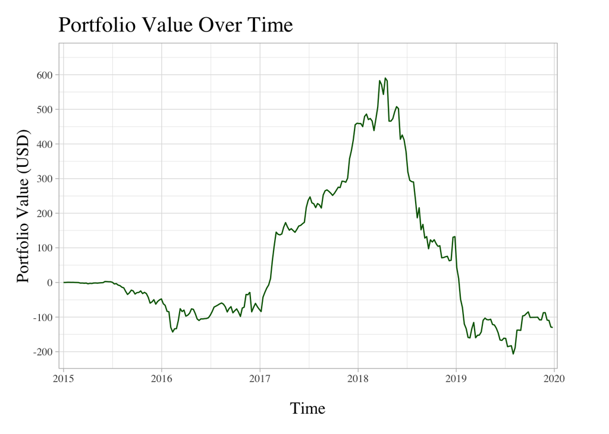

```r
# plot portfolio value
fig3_spv = ggplot(data = data.frame(Date = dates, Y = port_value),
                  aes(x = Date, y = Y)) +
      geom_line(color = "darkgreen") +
      theme_light(base_family = "Times") +
      theme(
        axis.title.x = element_text(size = 14, margin = margin(t = 15)),
        axis.title.y = element_text(size = 14, margin = margin(r = 1)),
        plot.title = element_text(size = 18),
        plot.margin = unit(c(0.5, 1.5, .5, .5), "cm")
      ) +
      labs(
        title = "Portfolio Value Over Time",
        x = "Time",
        y = "Portfolio Value (USD)"
      ) +
      scale_x_date(
        date_breaks = "1 year",
        date_labels = "%Y",
        expand = c(0.01, 0)
      ) +
      scale_y_continuous(
        labels = comma,
        breaks = pretty(range(port_value), n = 10),
        limits = c(min(port_value), max(port_value)*1.1)
      )
#ggsave("fig3_spv.pdf", plot = fig3_spv, device = "pdf", width = 8, height = 4)
fig3_spv
```

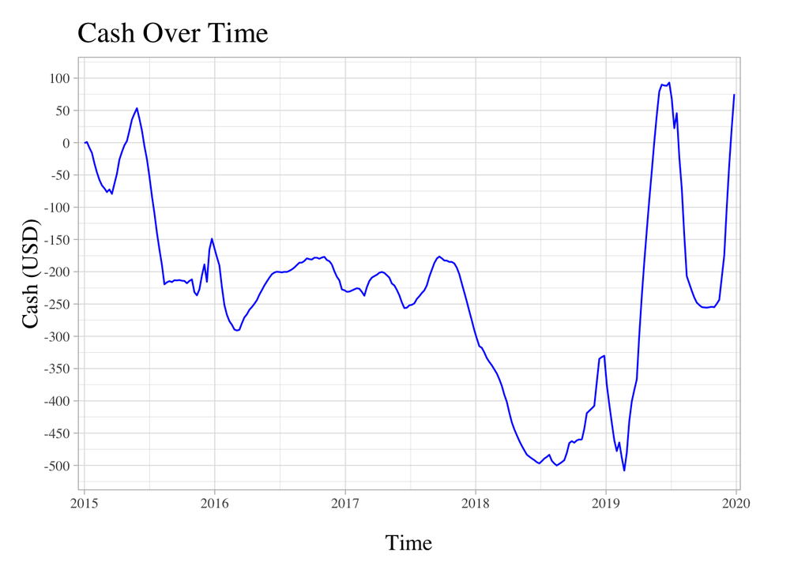

```r
# plot cash
fig4_scash = ggplot(data = data.frame(Date = dates, Y = cash), aes(x = Date, y = Y)) +
      geom_line(color = "blue") +
      theme_light(base_family = "Times") +
      theme(
        axis.title.x = element_text(size = 14, margin = margin(t = 15)),
        axis.title.y = element_text(size = 14, margin = margin(r = 1)),
        plot.title = element_text(size = 18),
        plot.margin = unit(c(0.5, 1.5, .5, .5), "cm")
      ) +
      labs(
        title = "Cash Over Time",
        x = "Time",
        y = "Cash (USD)"
      ) +
      scale_x_date(
        date_breaks = "1 year",
        date_labels = "%Y",
        expand = c(0.01, 0)
      ) +
      scale_y_continuous(
        labels = comma,
        breaks = pretty(range(cash), n = 10),
        limits = c(min(cash), max(cash)*1.1)
      )
#gsave("fig4_scash.pdf", plot = fig4_scash, device = "pdf", width = 8, height = 4)
fig4_scash
```

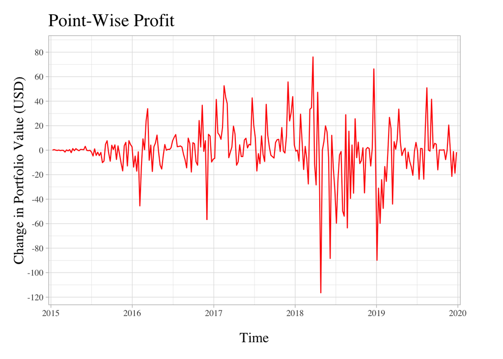

```r
# Plot point-wise profit
profit_diff = c(diff(port_value))
ggplot(data = data.frame(Date = dates[-1], Y = profit_diff), aes(x = Date, y = Y)) +
      geom_line(color = "red") +
      theme_light(base_family = "Times") +
      theme(
        axis.title.x = element_text(size = 14, margin = margin(t = 15)),
        axis.title.y = element_text(size = 14, margin = margin(r = 1)),
        plot.title = element_text(size = 18),
        plot.margin = unit(c(0.5, 1.5, .5, .5), "cm")
      ) +
      labs(
        title = "Point-Wise Profit",
        x = "Time",
        y = "Change in Portfolio Value (USD)"
      ) +
      scale_x_date(
        date_breaks = "1 year",
        date_labels = "%Y",
        expand = c(0.01, 0)
      ) +
      scale_y_continuous(
        labels = comma,
        breaks = pretty(range(profit_diff), n = 10),
        limits = c(min(profit_diff), max(profit_diff)*1.1)
      )
```

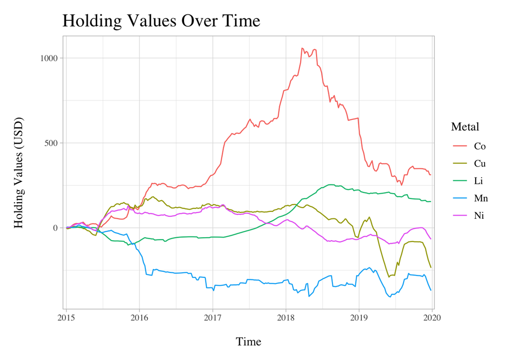

```r
# Plot holdings
holding_df = as.data.frame(holding_values)
names(holding_df) = colnames(holding_values)
holding_df$Date = dates
holding_long = pivot_longer(holding_df, cols = -Date, names_to = "Metal",
                             values_to = "Value")
fig5_sholding = ggplot(holding_long, aes(x = Date, y = Value, color = Metal)) +
  geom_line() +
  theme_light(base_family = "Times") +
  theme(
    axis.title.x = element_text(size = 12, margin = margin(t = 15)),
    axis.title.y = element_text(size = 12, margin = margin(r = 15)),
    plot.title = element_text(size = 18),
    legend.title = element_text(size = 12),
    legend.text = element_text(size = 10),
    plot.margin = unit(c(0.5, 0.5, 0.5, 0.5), "cm")
  ) +
  labs(
    title = "Holding Values Over Time",
    x = "Time",
    y = "Holding Values (USD)",
    color = "Metal"
  ) +
  scale_x_date(
    date_breaks = "1 year",
    date_labels = "%Y",
    expand = c(0.01, 0)
  )
#ggsave("fig5_sholding.pdf", plot = fig5_sholding, device = "pdf", width = 8, height = 4)
fig5_sholding
```

# Feature Regression on Profitability

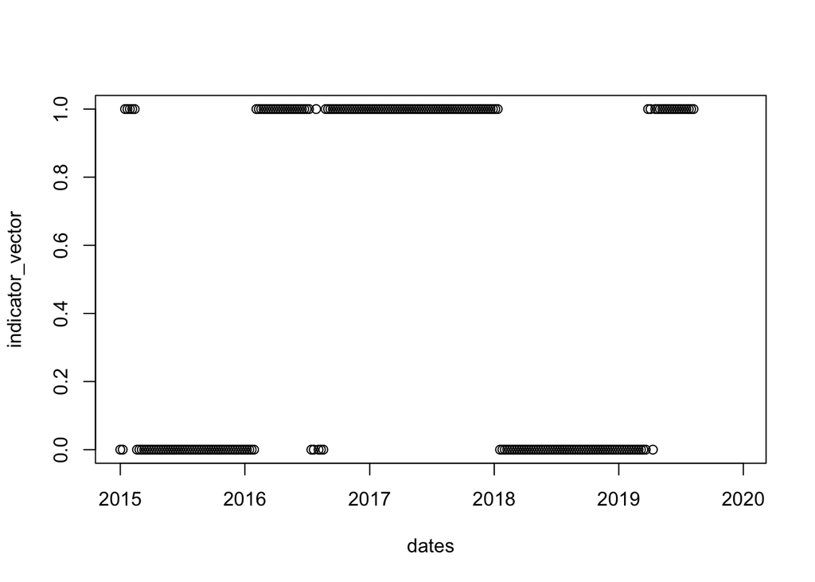

```r
# indicator vector of if portfolio value is higher than current value a month out
indicator_vector = rep(NA, length(port_value))
indicator_vector[1:(length(port_value) - 20)] =
    as.integer(port_value[1:(length(port_value) - 20)] <
                   port_value[21:length(port_value)])
plot(dates, indicator_vector)
```

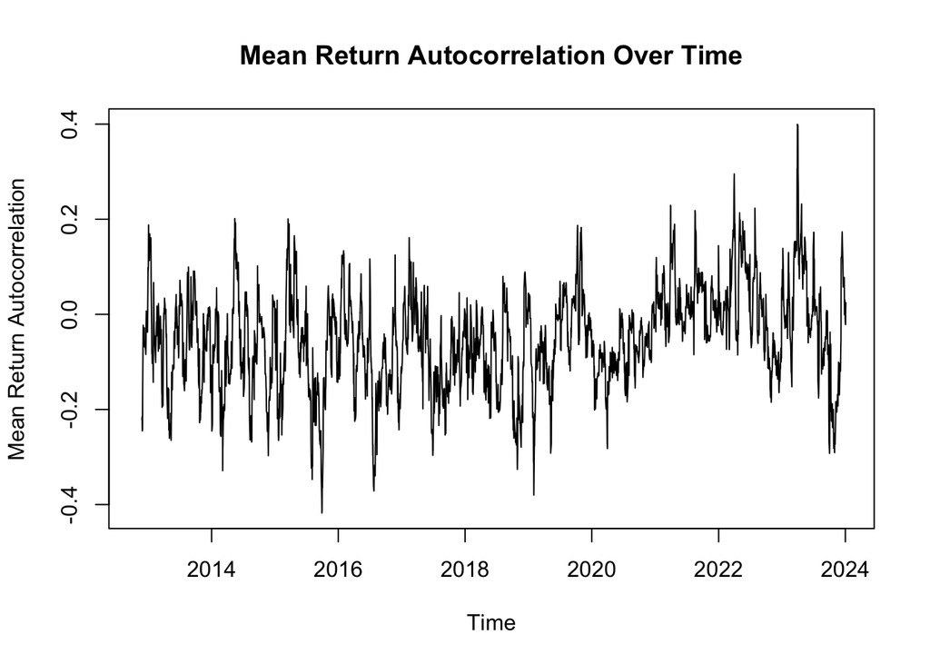

```r
logpricematrix = diff(log(data.matrix(PRICES)[,-1]))    # these are returns
# compute and plot rolling autocorrelation
rolling_autocorr = rollapply(logpricematrix, width=20,
    FUN=function(x) acf(x, lag.max=1, plot=FALSE)$acf[2], by.column=TRUE,
    align="right", fill=NA)
mean_autocorr = rowMeans(rolling_autocorr, na.rm = TRUE)
plot(PRICES$Date[-1], mean_autocorr, type = 'l', xlab = "Time",
    ylab = "Mean Return Autocorrelation", main = "Mean Return Autocorrelation Over Time")
```

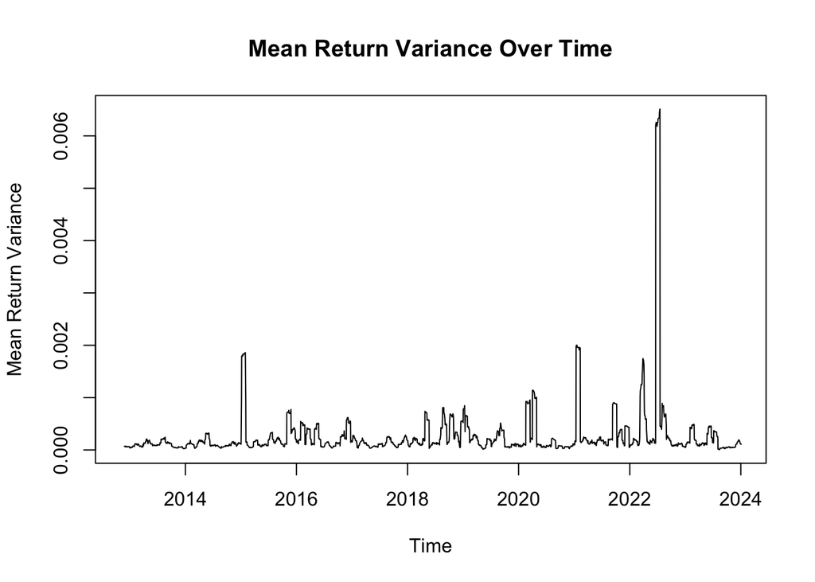

```r
# compute and plot rolling variance
rolling_variance = rollapply(logpricematrix, width=20, FUN=var, by.column=TRUE,
                             align="right", fill=NA)
mean_variance = rowMeans(rolling_variance, na.rm = TRUE)
plot(PRICES$Date[-1], mean_variance, type = 'l', xlab = "Time",
     ylab = "Mean Return Variance", main = "Mean Return Variance Over Time")
```

```r
autocorrs = mean_autocorr[PRICES$Date %in% dates]
variances = mean_variance[PRICES$Date %in% dates]
data_for_logit = data.frame(
  Indicator = indicator_vector[1:(length(indicator_vector) - 20)], # remove last 20 NAs
  Autocorr = autocorrs[1:(length(autocorrs) - 20)],  # and align these
  Variance = variances[1:(length(variances) - 20)]
)
data_for_logit = na.omit(data_for_logit)

# train and show logistic regression
logit = glm(Indicator ~ Variance + Autocorr, family = binomial(link = "logit"),
            data = data_for_logit)
summary(logit)
```

```
##
## Call:
## glm(formula = Indicator ~ Variance + Autocorr, family = binomial(link = "logit"),
##     data = data_for_logit)
##
## Deviance Residuals:
##    Min      1Q  Median      3Q     Max
## -1.337  -1.192   1.048   1.137   1.818
##
## Coefficients:
##              Estimate Std. Error z value Pr(>|z|)
## (Intercept)    0.2726     0.2085   1.308    0.191
## Variance    -825.8833   527.6848  -1.565    0.118
## Autocorr       0.7390     1.3034   0.567    0.571
##
## (Dispersion parameter for binomial family taken to be 1)
##
##     Null deviance: 334.09  on 240  degrees of freedom
## Residual deviance: 330.91  on 238  degrees of freedom
## AIC: 336.91
##
## Number of Fisher Scoring iterations: 4
```

# Evaluate Model on Out-of-Sample Data

### Make Predictions on Out-of-Sample Data

```r
BEGIN_oos= END_TRAINING + days(1)
END_oos= END_DATA
makepreds_oos = makepredictions(BEGIN_oos, 24, 5, END_oos)
```

```
## [1] "% times VECM used: 1"
```

```r
predictions_oos = makepreds_oos$aligned_prices
head(predictions_oos)
```

```
##         Date     Li_p     Co_p     Ni_p     Mn_p     Cu_p       vLi       vCo
## 1 2020-01-01 13.28085 10.37745 11.62483 7.354918 8.628527 0.1410032 0.4166466
## 2 2020-01-08 13.28025 10.34850 11.60714 7.358914 8.629410 0.1435602 0.4161831
## 3 2020-01-15 13.28201 10.37682 11.60290 7.362309 8.631535 0.1459462 0.4149940
## 4 2020-01-22 13.28129 10.36885 11.59357 7.362796 8.632314 0.1481695 0.4136081
## 5 2020-01-29 13.28164 10.39207 11.57769 7.405614 8.630854 0.1502372 0.4118188
## 6 2020-02-05 13.28087 10.44275 11.55507 7.405669 8.630712 0.1521557 0.4092981
##         vNi       vMn        vCu     Li_a     Co_a     Ni_a     Mn_a     Cu_a
## 1 0.1084555 0.1551086 0.04147235 13.27937 10.38282 11.63868 7.393263 8.639588
## 2 0.1081700 0.1562932 0.04102570 13.27937 10.35123 11.62178 7.393263 8.639588
## 3 0.1077958 0.1580855 0.04069809 13.27937 10.38268 11.61751 7.393263 8.639588
## 4 0.1077298 0.1598432 0.04035186 13.27937 10.37507 11.60642 7.393263 8.639588
## 5 0.1075495 0.1611775 0.03988156 13.27937 10.39070 11.59358 7.438384 8.639588
## 6 0.1072954 0.1625416 0.03956925 13.27937 10.43598 11.57025 7.438384 8.638703
##           ecLi       acLi       necLi         ecCo        acCo        necCo
```

[output cut: 20 more lines]

### Evaluate Out-of-Sample Data: RMSEs, directional accuracy, probability of randomness

```r
metrics_oos = evalmetrics(predictions_oos)
print("RMSEs:")
```

```
## [1] "RMSEs:"
```

```r
print(metrics_oos$rmses)
```

```
##         Li         Co         Ni         Mn         Cu
## 0.12015911 0.11643188 0.09159625 0.17947441 0.04864304
```

```r
print("Actual sds:")
```

```
## [1] "Actual sds:"
```

```r
print(metrics_oos$sd)
```

```
##         Li         Co         Ni         Mn         Cu
## 0.12550505 0.11734449 0.08973293 0.17773315 0.04798123
```

```r
print("Mean prediction for when changes are zero:")
```

```
## [1] "Mean prediction for when changes are zero:"
```

```r
print(metrics_oos$mz)
```

```
## [1] -0.0004346412
```

```r
print("Directional accuracy for nonzero changes:")
```

```
## [1] "Directional accuracy for nonzero changes:"
```

```r
print(metrics_oos$danz)
```

```
##        Li        Co        Ni        Mn        Cu
## 0.6971831 0.4607843 0.5219512 0.6375839 0.5121951
```

```r
print("Probability of obtaining this directional accuracy from a random model:")
```

```
## [1] "Probability of obtaining this directional accuracy from a random model:"
```

```r
print(metrics_oos$prob_random)
```

```
## [1] 0.0008824084
```

### Simulate and Evaluate Trading Strategy on Out-of-Sample Data

```r
results_oos = evaluate(predictions_oos, base_size, base_change)

H_oos = results_oos$H
P_oos = results_oos$P
holding_values_oos = H_oos*P_oos
colnames(holding_values_oos) = METALS
dates_oos = results_oos$dates
cash_oos = results_oos$cash
port_value_oos = results_oos$port_value
trades_oos = results_oos$trades
print(paste0("Annualized sharpe = ", results_oos$annualized_sharpe))
```

```
## [1] "Annualized sharpe = 0.256785818160186"
```

```r
print(paste0("Average return = ", results_oos$Rp))
```

```
## [1] "Average return = 0.114745227261595"
```

```r
print(paste0("Returns sd = ", results_oos$sp))
```

```
## [1] "Returns sd = 3.14555704613833"
```

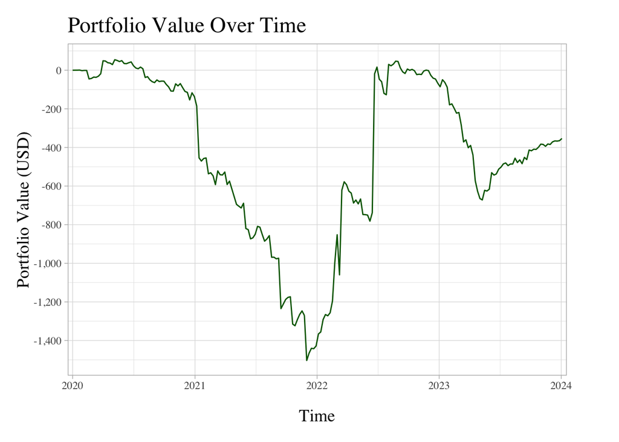

```r
# plot portfolio value
fig6_oospv = ggplot(data = data.frame(Date = dates_oos, Y = port_value_oos),
                    aes(x = Date, y = Y)) +
      geom_line(color = "darkgreen") +
      theme_light(base_family = "Times") +
      theme(
        axis.title.x = element_text(size = 14, margin = margin(t = 15)),
        axis.title.y = element_text(size = 14, margin = margin(r = 1)),
        plot.title = element_text(size = 18),
        plot.margin = unit(c(0.5, 1.5, .5, .5), "cm")
      ) +
      labs(
        title = "Portfolio Value Over Time",
        x = "Time",
        y = "Portfolio Value (USD)"
      ) +
      scale_x_date(
        date_breaks = "1 year",
        date_labels = "%Y",
        expand = c(0.01, 0)
      ) +
      scale_y_continuous(
        labels = comma,
        breaks = pretty(range(port_value_oos), n = 10),
        limits = c(min(port_value_oos), max(port_value_oos)*1.1)
      )
#ggsave("fig6_oospv.pdf", plot = fig6_oospv, device = "pdf", width = 8, height = 4)
fig6_oospv
```

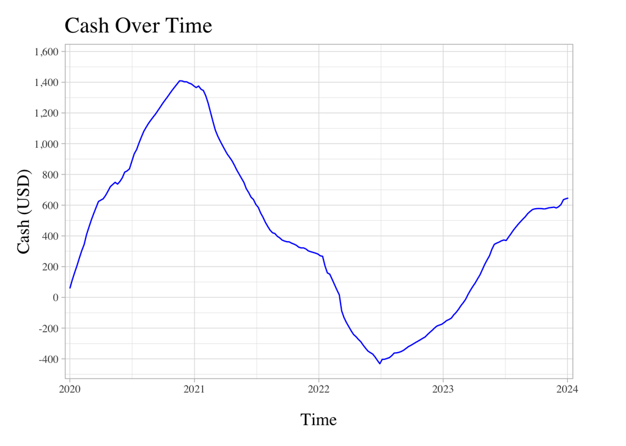

```r
# plot cash
fig7_ooscash = ggplot(data = data.frame(Date = dates_oos, Y = cash_oos),
                      aes(x = Date, y = Y)) +
      geom_line(color = "blue") +
      theme_light(base_family = "Times") +
      theme(
        axis.title.x = element_text(size = 14, margin = margin(t = 15)),
        axis.title.y = element_text(size = 14, margin = margin(r = 1)),
        plot.title = element_text(size = 18),
        plot.margin = unit(c(0.5, 1.5, .5, .5), "cm")
      ) +
      labs(
        title = "Cash Over Time",
        x = "Time",
        y = "Cash (USD)"
      ) +
      scale_x_date(
        date_breaks = "1 year",
        date_labels = "%Y",
        expand = c(0.01, 0)
      ) +
      scale_y_continuous(
        labels = comma,
        breaks = pretty(range(cash_oos), n = 10),
        limits = c(min(cash_oos), max(cash_oos)*1.1)
      )
#ggsave("fig7_ooscash.pdf", plot = fig7_ooscash, device = "pdf", width = 8, height = 4)
fig7_ooscash
```

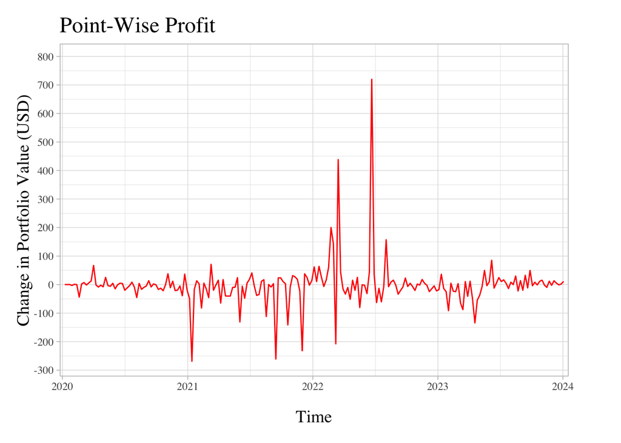

```r
# Plot point-wise profit
profit_diff_oos = c(diff(port_value_oos))
ggplot(data = data.frame(Date = dates_oos[-1], Y = profit_diff_oos),
       aes(x = Date, y = Y)) +
      geom_line(color = "red") +
      theme_light(base_family = "Times") +
      theme(
        axis.title.x = element_text(size = 14, margin = margin(t = 15)),
        axis.title.y = element_text(size = 14, margin = margin(r = 1)),
        plot.title = element_text(size = 18),
        plot.margin = unit(c(0.5, 1.5, .5, .5), "cm")
      ) +
      labs(
        title = "Point-Wise Profit",
        x = "Time",
        y = "Change in Portfolio Value (USD)"
      ) +
      scale_x_date(
        date_breaks = "1 year",
        date_labels = "%Y",
        expand = c(0.01, 0)
      ) +
      scale_y_continuous(
        labels = comma,
        breaks = pretty(range(profit_diff_oos), n = 10),
        limits = c(min(profit_diff_oos), max(profit_diff_oos)*1.1)
      )
```

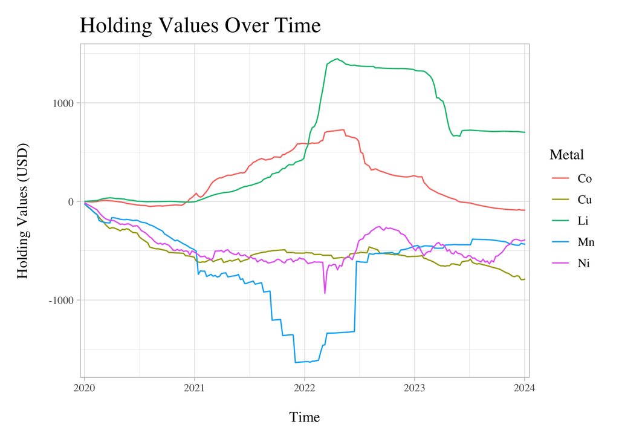

```r
# Plot holding values
holding_df_oos = as.data.frame(holding_values_oos)
names(holding_df_oos) = colnames(holding_values_oos)
holding_df_oos$Date = dates_oos
holding_long_oos = pivot_longer(holding_df_oos, cols = -Date,
                                 names_to = "Metal", values_to = "Value")
fig8_oosholding = ggplot(holding_long_oos, aes(x = Date, y = Value, color = Metal)) +
  geom_line() +
  theme_light(base_family = "Times") +
  theme(
    axis.title.x = element_text(size = 12, margin = margin(t = 15)),
    axis.title.y = element_text(size = 12, margin = margin(r = 15)),
    plot.title = element_text(size = 18),
    legend.title = element_text(size = 12),
    legend.text = element_text(size = 10),
    plot.margin = unit(c(0.5, 0.5, 0.5, 0.5), "cm")
  ) +
  labs(
    title = "Holding Values Over Time",
    x = "Time",
    y = "Holding Values (USD)",
    color = "Metal"
  ) +
  scale_x_date(
    date_breaks = "1 year",
    date_labels = "%Y",
    expand = c(0.01, 0)
  )
#ggsave("fig8_oosholding.pdf", plot = fig8_oosholding, device = "pdf", width = 8, height = 4)
fig8_oosholding
```

# Visualize Cointegrating Relationships

```r
makepreds_full = makepredictions(BEGIN, 24, 5, END_DATA)
```

```
## [1] "% times VECM used: 0.78343949044586"
```

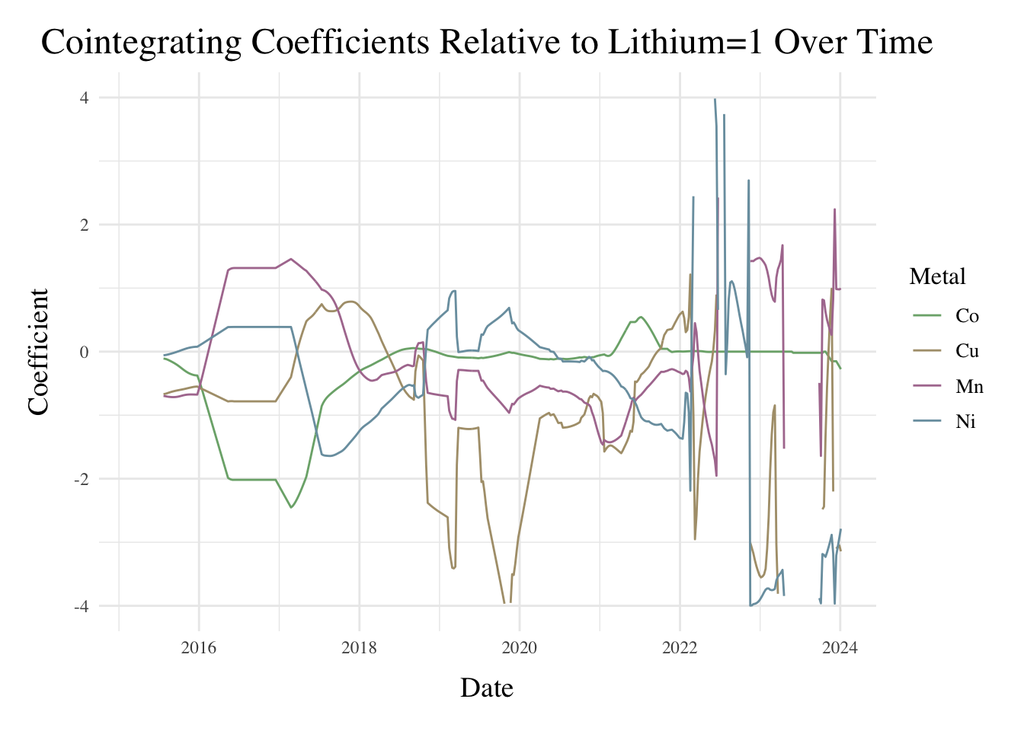

```r
# access cointegration vectors
rels1_full = makepreds_full$rels
rels1_full_smoothed = rels1_full

# take rolling average to smoothen
for(metal in c("Co", "Ni", "Mn", "Cu")) {
  rels1_full_smoothed[[metal]] = rollmean(rels1_full[[metal]], 20, fill = NA,
                                          align = "right")
}

rels1_long = pivot_longer(
  data = rels1_full_smoothed,
  cols = c(Co, Ni, Mn, Cu),
  names_to = "Metal",
  values_to = "Coefficient"
)
fig9_cvec1 = ggplot(data = rels1_long, aes(x = Date, y = Coefficient, color = Metal)) +
  geom_line() +
  labs(title = "Cointegrating Coefficients Relative to Lithium=1 Over Time",
       y = "Coefficient", x = "Date") +
  scale_color_manual(
    values = c("Co" = "#7CAE7A", "Ni" = "#7A9EAE", "Mn" = "#AE7A9E", "Cu" = "#AE9E7A"),
    name = "Metal"
  ) +
  theme_minimal(base_family = "Times") +
  theme(
    plot.title = element_text(size = 18, hjust = 0.5),
    axis.title.x = element_text(size = 14, margin = margin(t = 10)),
    axis.title.y = element_text(size = 14, margin = margin(r = 10)),
    legend.title = element_text(size = 12),
    legend.text = element_text(size = 10),
    plot.margin = unit(c(.5, .5, .5, .5), "cm")
  ) +
  ylim(-4, 4)
#ggsave("fig9_cvec1.pdf", plot = fig9_cvec1, device = "pdf", width = 8, height = 4)
fig9_cvec1
```